# GENEActiv and Phase Angle in IIM — Bootstrap Mixed-Model Report

Veronika Balounová

Compiled on: **2026-05-04** Last updated **2026-05-04

# 1 Aim

This report summarizes bootstrap mixed-model results from the `lmer_srovnani_2_promennych_interakce_bootstrap_bmi.R` analysis. The clinical question is whether longitudinal wrist-accelerometry output (`ig_gradient_enmo`) changes over time in patients with idiopathic inflammatory myopathy (IIM), and whether the signal is independently associated with age, sex, between-patient body cell mass (BCM), and between-patient body mass index (BMI).

The report is written for clinical interpretation. The statistical model is treated as a robustness analysis rather than as a causal model.

# 2 Abbreviations

**BCM**: body cell mass. **BMI**: body mass index. **BIA**: bioelectrical impedance analysis. **CI**: confidence interval. **CK**: creatine kinase. **ENMO**: Euclidean Norm Minus One, an acceleration metric commonly used for raw accelerometer data. **IIM**: idiopathic inflammatory myopathy. **LMM**: linear mixed model. **M0, M3, M6, M18, M30, M48**: study visits at baseline and months 3, 6, 18, 30, and 48. **PhA**: phase angle. **SE**: standard error. **VIF**: variance inflation factor.

# 3 Data Overview

The source dataset contains 219 observations from 64 patients. The model-eligible dataset, after deriving between-patient BCM and BMI and removing records with missing model variables, contains 215 observations from 63 patients.

Data availability

| metric | value |
| --- | --- |
| Rows in source data | 219 |
| Unique patients in source data | 64 |
| Rows eligible for model | 215 |
| Unique patients eligible for model | 63 |

Visit distribution

| exam | n_source | n_model_eligible |
| --- | --- | --- |
| M0 | 56 | 55 |
| M3 | 52 | 52 |
| M6 | 56 | 55 |
| M18 | 39 | 38 |
| M30 | 13 | 12 |
| M48 | 3 | 3 |

Continuous-variable summary in source data

| variable | value |
| --- | --- |
| age_median | 57.19 |
| age_iqr | 20.96 |
| bmi_median | 26.95 |
| bmi_iqr | 5.75 |
| bcm_median | 22.60 |
| bcm_iqr | 8.20 |
| phase_angle_median | 4.70 |
| phase_angle_iqr | 1.20 |
| ig_gradient_enmo_median | −2.77 |
| ig_gradient_enmo_iqr | 0.20 |

The raw dataset is longitudinal and unbalanced. Most records are at M0, M3, and M6; late follow-up is sparse, especially M48. This matters for interpretation: the M48 coefficient is directionally strong, but it is estimated from fewer available observations than the earlier visits.

# 4 Methods

The fitted full-sample model was:

```
## ig_gradient_enmo ~ exam + age + sex + bcm_between + bmi_between +      (1 | boot_id)
```

The model uses `ig_gradient_enmo` as the dependent variable. The fixed effects are visit, age, sex, between-patient BCM, and between-patient BMI. A random intercept is included for `boot_id`, which represents the patient or bootstrap cluster. Models were fitted by maximum likelihood with `lme4::lmer` (`REML = FALSE`), using the `bobyqa` optimizer.

For bootstrap inference, 5000 bootstrap samples were generated. Each cycle sampled 50 patients with replacement. Within each bootstrap cycle, the preprocessing was repeated, including derivation of between-patient components for BCM and BMI using group-mean decomposition. Both raw and standardized models were fitted. In the standardized model, the response and continuous predictors were z-standardized within the bootstrap dataset; therefore, standardized coefficients are comparable by effect size.

The bootstrap summary reports the mean and median coefficient across successful bootstrap fits, bootstrap SE, percentile 95% CI, two-sided bootstrap p value, and the proportion of bootstrap coefficients above or below zero.

# 5 Model Stability

Bootstrap convergence status

| model_type | n_total | n_converged | n_failed | n_singular | median_n_obs | median_n_groups |
| --- | --- | --- | --- | --- | --- | --- |
| raw | 5,000 | 5,000 | 0 | 0 | 171 | 171 |
| standardized | 5,000 | 5,000 | 0 | 0 | 171 | 171 |

All 5000 bootstrap cycles converged for both raw and standardized models. No singular fits were detected. The median bootstrap model used 171 observations and 171 bootstrap clusters. This is a technically important result: the main findings are not driven by frequent model failure or unstable random-effect estimation.

# 6 Full-Sample Model

Full-sample fixed effects: raw model

| Parameter | Coefficient | SE | 95% CI | t | df_error | p |
| --- | --- | --- | --- | --- | --- | --- |
| Intercept (baseline M0, female reference) | −2.548 | 0.137 | -2.819 to -2.278 | −18.596 | 203 | <0.001 |
| M3 vs M0 | 0.062 | 0.023 | 0.016 to 0.107 | 2.651 | 203 | 0.009 |
| M6 vs M0 | 0.071 | 0.023 | 0.026 to 0.115 | 3.126 | 203 | 0.002 |
| M18 vs M0 | 0.105 | 0.026 | 0.055 to 0.156 | 4.090 | 203 | <0.001 |
| M30 vs M0 | 0.100 | 0.040 | 0.021 to 0.179 | 2.500 | 203 | 0.013 |
| M48 vs M0 | 0.169 | 0.075 | 0.021 to 0.317 | 2.249 | 203 | 0.026 |
| Age | −0.003 | 0.001 | -0.005 to -0.001 | −2.452 | 203 | 0.015 |
| Male sex vs female | 0.055 | 0.053 | -0.049 to 0.159 | 1.039 | 203 | 0.300 |
| Between-patient BCM | 0.006 | 0.004 | -0.002 to 0.015 | 1.479 | 203 | 0.141 |
| Between-patient BMI | −0.011 | 0.004 | -0.019 to -0.002 | −2.446 | 203 | 0.015 |

The full-sample model shows a consistent increase in `ig_gradient_enmo` at all post-baseline visits. Compared with M0, coefficients are positive at M3, M6, M18, M30, and M48. Age and BMI show negative associations, whereas male sex and BCM do not show clear independent effects in the full-sample model.

Collinearity diagnostics for the full-sample model

| Term | VIF | VIF_CI_low | VIF_CI_high | SE_factor | Tolerance | Tolerance_CI_low | Tolerance_CI_high |
| --- | --- | --- | --- | --- | --- | --- | --- |
| exam | 1.03 | 1.00 | 3.34 | 1.02 | 0.97 | 0.30 | 1.00 |
| age | 1.09 | 1.02 | 1.47 | 1.04 | 0.92 | 0.68 | 0.98 |
| sex | 2.48 | 2.06 | 3.07 | 1.58 | 0.40 | 0.33 | 0.49 |
| bcm_between | 2.77 | 2.28 | 3.45 | 1.67 | 0.36 | 0.29 | 0.44 |
| bmi_between | 1.23 | 1.10 | 1.51 | 1.11 | 0.81 | 0.66 | 0.91 |

VIF values are below conventional high-collinearity thresholds. BCM and sex have the highest VIFs, but neither reaches a level that would by itself invalidate the model. The covariate estimates should still be read as mutually adjusted associations, not as isolated biological effects.

# 7 Bootstrap Results

Bootstrap summary: raw coefficients

| Parameter | Median coefficient | Bootstrap SE | 95% percentile CI | Bootstrap p | Pr(coef > 0) | Pr(coef < 0) | Direction |
| --- | --- | --- | --- | --- | --- | --- | --- |
| Intercept (baseline M0, female reference) | -2.544 | 0.158 | -2.843 to -2.229 | <0.001 | 0.000 | 1.000 | negative |
| Age | -0.003 | 0.001 | -0.006 to -0.000 | 0.031 | 0.016 | 0.984 | negative |
| Between-patient BCM | 0.006 | 0.007 | -0.006 to 0.021 | 0.329 | 0.835 | 0.165 | uncertain |
| Between-patient BMI | -0.011 | 0.004 | -0.020 to -0.002 | 0.013 | 0.007 | 0.993 | negative |
| M18 vs M0 | 0.105 | 0.036 | 0.036 to 0.177 | 0.002 | 0.999 | 0.001 | positive |
| M3 vs M0 | 0.062 | 0.028 | 0.010 to 0.119 | 0.016 | 0.992 | 0.008 | positive |
| M30 vs M0 | 0.102 | 0.038 | 0.026 to 0.174 | 0.010 | 0.995 | 0.005 | positive |
| M48 vs M0 | 0.162 | 0.079 | 0.058 to 0.335 | <0.001 | 1.000 | 0.000 | positive |
| M6 vs M0 | 0.070 | 0.026 | 0.022 to 0.124 | 0.004 | 0.998 | 0.002 | positive |
| Male sex vs female | 0.054 | 0.080 | -0.131 to 0.185 | 0.492 | 0.754 | 0.246 | uncertain |

The raw bootstrap model confirms that post-baseline visits have positive coefficients. The 95% percentile CI excludes zero for M3, M6, M18, M30, and M48. The estimated raw increase is approximately 0.062 at M3, 0.070 at M6, 0.105 at M18, 0.102 at M30, and 0.162 at M48, all relative to M0. Because `ig_gradient_enmo` is on a transformed accelerometry scale, the most useful clinical reading is the direction and robustness of the change rather than a direct bedside unit conversion.

Age has a small but robust negative coefficient. BMI also has a robust negative between-patient association. BCM is mostly positive but its percentile CI crosses zero; therefore, the data do not support a definitive independent BCM effect in this model. Male sex is not estimated with sufficient precision to support a sex-specific conclusion.

Bootstrap summary: standardized coefficients

| Parameter | Median coefficient | Bootstrap SE | 95% percentile CI | Bootstrap p | Pr(coef > 0) | Pr(coef < 0) | Direction |
| --- | --- | --- | --- | --- | --- | --- | --- |
| Intercept (baseline M0, female reference) | -0.403 | 0.221 | -0.853 to 0.017 | 0.061 | 0.030 | 0.970 | uncertain |
| Age, z-score | -0.221 | 0.104 | -0.428 to -0.024 | 0.031 | 0.016 | 0.984 | negative |
| Between-patient BCM, z-score | 0.209 | 0.223 | -0.207 to 0.669 | 0.329 | 0.835 | 0.165 | uncertain |
| Between-patient BMI, z-score | -0.240 | 0.103 | -0.452 to -0.048 | 0.013 | 0.007 | 0.993 | negative |
| M18 vs M0 | 0.578 | 0.190 | 0.219 to 0.957 | 0.002 | 0.999 | 0.001 | positive |
| M3 vs M0 | 0.349 | 0.163 | 0.049 to 0.689 | 0.016 | 0.992 | 0.008 | positive |
| M30 vs M0 | 0.562 | 0.213 | 0.145 to 0.997 | 0.010 | 0.995 | 0.005 | positive |
| M48 vs M0 | 0.893 | 0.447 | 0.327 to 1.926 | <0.001 | 1.000 | 0.000 | positive |
| M6 vs M0 | 0.390 | 0.148 | 0.121 to 0.702 | 0.004 | 0.998 | 0.002 | positive |
| Male sex vs female | 0.299 | 0.442 | -0.669 to 1.060 | 0.492 | 0.754 | 0.246 | uncertain |

The standardized model makes the relative effect sizes easier to compare. The strongest standardized visit coefficient is M48, followed by M18 and M30, but this must be tempered by the sparse M48 data. Age and BMI have similar standardized negative associations (approximately -0.22 and -0.24 SD, respectively). BCM is positive (approximately +0.21 SD) but statistically uncertain because its bootstrap interval includes zero.

# 8 Figures

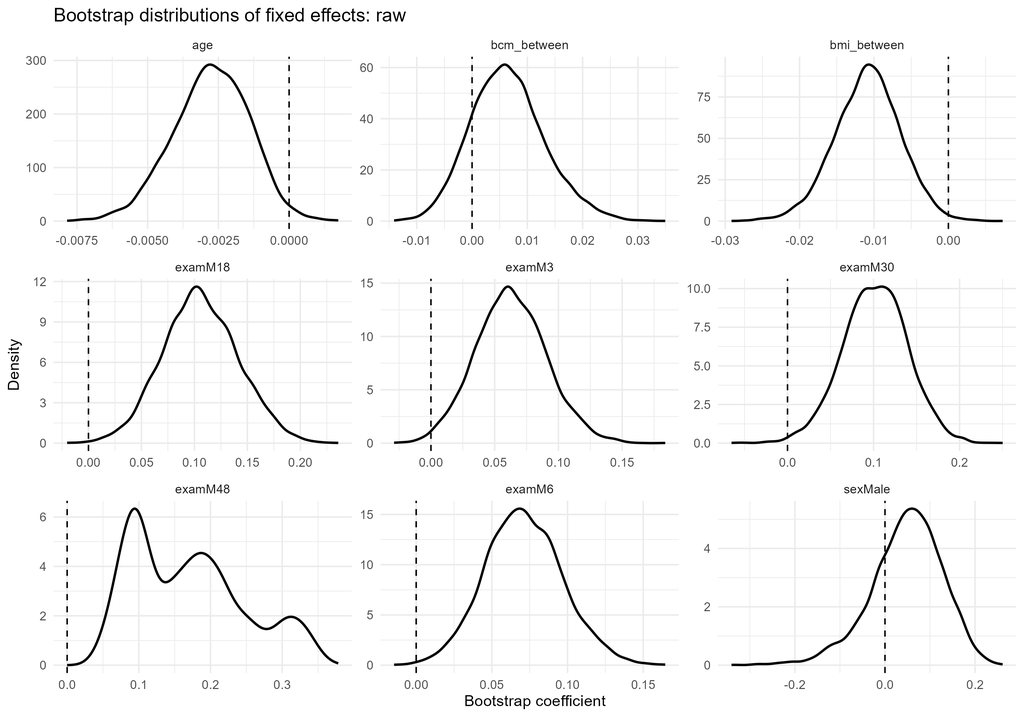

Raw-model bootstrap coefficient distributions and percentile confidence intervals.

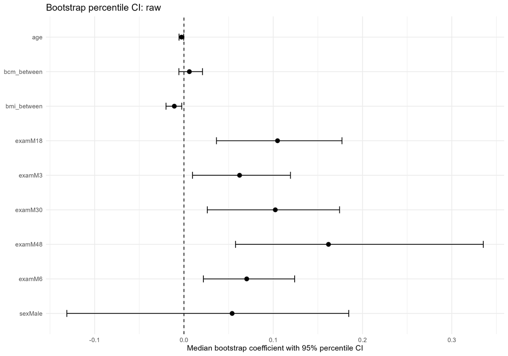

Raw-model bootstrap coefficient distributions and percentile confidence intervals.

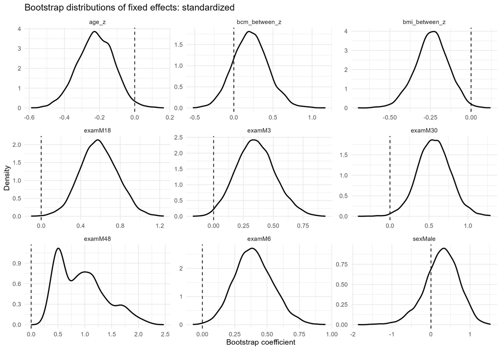

Standardized-model bootstrap coefficient distributions and percentile confidence intervals.

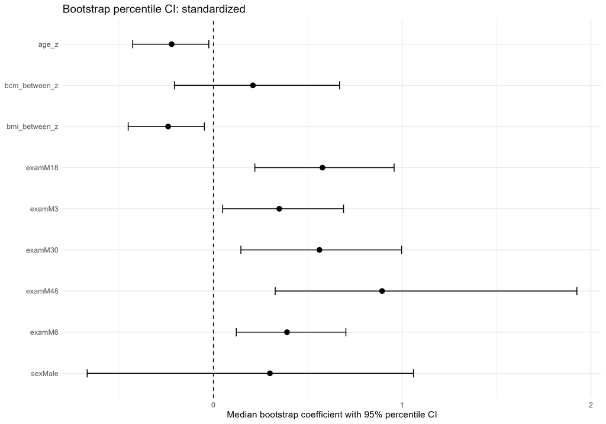

Standardized-model bootstrap coefficient distributions and percentile confidence intervals.

The density plots show the empirical bootstrap distribution for each fixed-effect coefficient. A distribution concentrated on one side of zero supports directional robustness. The forest plots summarize the median bootstrap coefficient and the 95% percentile CI. The visual pattern is consistent with the tables: visit effects are consistently positive, age and BMI are consistently negative, while BCM and sex are less certain.

# 9 Table and File Dictionary

The folder contains both human-readable and machine-readable versions of the results:

- `bootstrap_lmer_report.xlsx`: Excel workbook with seven sheets. The most important sheets are `full_sample_parameters_raw`, `full_sample_collinearity_raw`, `bootstrap_summary`, `bootstrap_status`, `bootstrap_all_parameters`, and `failed_boots`.
- `bootstrap_summary.csv` / `bootstrap_summary.rds`: compact bootstrap summary by model type and fixed-effect parameter.
- `bootstrap_all_parameters.csv` / `bootstrap_all_parameters.rds`: coefficient-level output from every bootstrap model. This table is the audit trail for the bootstrap distributions.
- `bootstrap_status.csv` / `bootstrap_status.rds`: convergence and singularity summary for raw and standardized models.
- `full_sample_model_raw.rds`: fitted `lmerMod` object for the full-sample raw model.
- `bootstrap_density_raw.png` and `bootstrap_density_standardized.png`: density plots of bootstrap coefficient distributions.
- `bootstrap_forest_raw.png` and `bootstrap_forest_standardized.png`: forest plots of median bootstrap coefficients with percentile CI.

Column definitions:

- `model_type`: raw or standardized model. In the standardized model, continuous predictors and the response are z-standardized.
- `Parameter`: model coefficient. `examM3`, `examM6`, `examM18`, `examM30`, and `examM48` are visit contrasts relative to M0. `sexMale` is male sex relative to female. `bcm_between` and `bmi_between` are between-patient components of BCM and BMI.
- `n_success`: number of successful bootstrap fits contributing to the parameter summary.
- `estimate_mean`, `estimate_median`: mean and median bootstrap coefficient.
- `boot_se`: standard deviation of the bootstrap coefficient distribution.
- `ci_low_percentile`, `ci_high_percentile`: 2.5th and 97.5th percentiles of the bootstrap coefficient distribution.
- `p_boot_two_sided`: empirical two-sided bootstrap p value calculated from the proportion of coefficients on either side of zero.
- `prop_positive`, `prop_negative`: proportion of bootstrap coefficients greater than or less than zero.
- `Coefficient`, `SE`, `CI_low`, `CI_high`, `t`, `df_error`, `p`: fixed effect estimate and model-based uncertainty from a single fitted model.
- `VIF`: variance inflation factor. Higher values indicate stronger collinearity with other predictors.
- `Tolerance`: reciprocal information to VIF; lower values indicate stronger collinearity.
- `boot_id`: bootstrap replicate number in the coefficient table; in the fitted model formula, `boot_id` also identifies the patient or bootstrap cluster for the random intercept.
- `converged`, `singular`, `error_message`: model fit diagnostics.
- `n_obs`, `n_groups`: number of model observations and random-effect groups used in a fitted bootstrap model.

# 10 Clinical Interpretation

From a clinical perspective, the most reproducible signal is the increase in accelerometer-derived `ig_gradient_enmo` after baseline. This supports the interpretation that longitudinal accelerometry can capture change in physical behavior or functional status in IIM. The finding is biologically plausible because accelerometer-derived physical activity has been proposed as a useful outcome domain in IIM, where standard clinical measures may not fully capture day-to-day functional capacity. A review of accelerometer-derived physical activity in IIM concluded that the field is still developing, but that accelerometry has promise for disease-activity and intervention assessment ([Oldroyd et al., 2019](https://pmc.ncbi.nlm.nih.gov/articles/PMC6805320/)). An adult IIM study also described physical activity monitoring as a promising outcome measure ([Bachasson et al., 2017](https://pubmed.ncbi.nlm.nih.gov/28566549/)).

The negative age effect indicates that older patients tend to have lower accelerometry signal after adjustment for visit, sex, BCM, and BMI. This is clinically expected and should be treated as an important confounder in future models of activity and muscle status.

The negative BMI effect is also clinically meaningful. Higher BMI can reduce ambulatory activity, alter wrist-accelerometer signal, and partly mask muscle-quality or disease-activity relationships. Because the model uses the between-patient BMI component, this result should be read as: patients with higher average BMI across follow-up tend to have lower `ig_gradient_enmo`, independent of visit and the other covariates.

BCM is directionally positive but uncertain. This fits the clinical expectation that greater cellular/muscle mass may relate to better activity, but the current dataset does not provide strong independent evidence once BMI, age, sex, and visit are included. In a manuscript, this should be presented as supportive but not confirmatory.

Phase angle is not the dependent variable in this bootstrap model, but it is central to the broader biological context. BIA-derived phase angle is commonly interpreted as a marker related to cell membrane integrity, fluid distribution, nutritional status, and muscle quality. Reviews and clinical studies support its relevance for muscle quality and sarcopenia assessment ([Norman et al., 2012](https://pubmed.ncbi.nlm.nih.gov/22698802/); [Akamatsu et al., 2022](https://pubmed.ncbi.nlm.nih.gov/34845859/); [Di Vincenzo et al., 2021](https://pubmed.ncbi.nlm.nih.gov/33183880/)). In IIM, where inflammation, muscle damage, glucocorticoid exposure, fatigue, and deconditioning can coexist, phase angle and accelerometry should be interpreted as complementary functional-bioelectrical readouts rather than interchangeable measures.

# 11 Manuscript-Oriented Summary

In a longitudinal IIM dataset of 64 patients and 219 observations, bootstrap mixed-effects modelling showed robust positive visit effects for `ig_gradient_enmo` after baseline. The analysis used 5000 bootstrap cycles with patient-level resampling and repeated preprocessing within each cycle. All raw and standardized bootstrap models converged without singular fits. Compared with M0, visit coefficients were consistently positive from M3 through M48. Age and between-patient BMI were independently and robustly negatively associated with `ig_gradient_enmo`. Between-patient BCM showed a positive but statistically uncertain association, and male sex was not clearly associated with the outcome.

These results support the use of accelerometer-derived activity measures as a longitudinal functional readout in IIM. The findings also indicate that age and BMI must be retained as clinically relevant covariates in models linking activity, body composition, and phase angle. The sparse late follow-up, particularly M48, should be explicitly acknowledged as a limitation.

# 12 References

- Akamatsu Y, Kusakabe T, Arai H, et al. Phase angle from bioelectrical impedance analysis is a useful indicator of muscle quality. *Journal of Cachexia, Sarcopenia and Muscle*. 2022;13:180-189. doi: [10.1002/jcsm.12860](https://pubmed.ncbi.nlm.nih.gov/34845859/).
- Bachasson D, Landon-Cardinal O, Benveniste O, Hogrel JY, Allenbach Y. Physical activity monitoring: A promising outcome measure in idiopathic inflammatory myopathies. *Neurology*. 2017;89:101-103. doi: [10.1212/WNL.0000000000004061](https://pubmed.ncbi.nlm.nih.gov/28566549/).
- Bates D, Mächler M, Bolker B, Walker S. Fitting linear mixed-effects models using lme4. *Journal of Statistical Software*. 2015;67:1-48. doi: [10.18637/jss.v067.i01](https://www.jstatsoft.org/v67/i01/).
- Di Vincenzo O, Marra M, Di Gregorio A, Pasanisi F, Scalfi L. Bioelectrical impedance analysis-derived phase angle in sarcopenia: A systematic review. *Clinical Nutrition*. 2021;40:3052-3061. doi: [10.1016/j.clnu.2020.10.048](https://pubmed.ncbi.nlm.nih.gov/33183880/).
- Efron B. Bootstrap methods: Another look at the jackknife. *The Annals of Statistics*. 1979;7:1-26. doi: 10.1214/aos/1176344552.
- Norman K, Stobäus N, Pirlich M, Bosy-Westphal A. Bioelectrical phase angle and impedance vector analysis: clinical relevance and applicability of impedance parameters. *Clinical Nutrition*. 2012;31:854-861. doi: [10.1016/j.clnu.2012.05.008](https://pubmed.ncbi.nlm.nih.gov/22698802/).
- Oldroyd A, Little MA, Dixon W, Chinoy H. A review of accelerometer-derived physical activity in the idiopathic inflammatory myopathies. *BMC Rheumatology*. 2019;3:41. doi: [10.1186/s41927-019-0088-1](https://pmc.ncbi.nlm.nih.gov/articles/PMC6805320/).